# Is the coding-quality ranking real, or just "who agrees with Opus"?

Every earlier chart scored models against **Opus** as the gold. But Opus isn't ground truth — it's one model's opinion. So we re-scored the same 30-post coding run against **three** model-golds — `Opus`, `gpt-5.6-luna`, and `gpt-5.6-sol` — each time with the *same* Opus equivalence-judge, so the only thing that changes is which model's codings are treated as truth. Three questions: does the ranking survive a change of gold, how much do the three authorities disagree, and does each gold favour its own lab?

*(loaded — 23 models scored across 3 golds)*

## 1. Every model against all three golds

Sorted by error vs Sol. A model has a gap where it *is* that gold (a model can't be scored against itself).

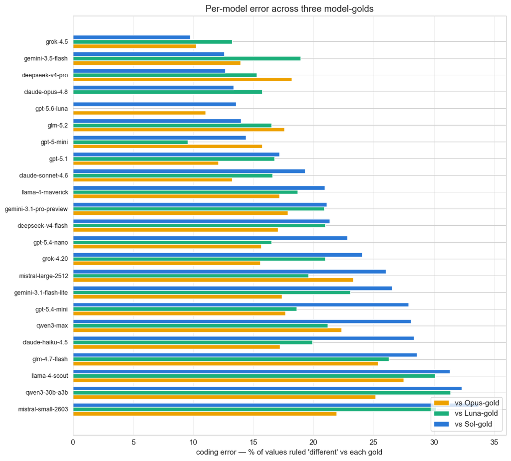

| model | vsOpus | vsLuna | vsSol |
| --- | --- | --- | --- |
| grok-4.5 | 10% | 13% | 10% |
| gemini-3.5-flash | 14% | 19% | 13% |
| deepseek-v4-pro | 18% | 15% | 13% |
| claude-opus-4.8 | — (gold) | 16% | 13% |
| gpt-5.6-luna | 11% | — (gold) | 14% |
| glm-5.2 | 18% | 16% | 14% |
| gpt-5-mini | 16% | 10% | 14% |
| gpt-5.1 | 12% | 17% | 17% |
| claude-sonnet-4.6 | 13% | 17% | 19% |
| llama-4-maverick | 17% | 19% | 21% |
| gemini-3.1-pro-preview | 18% | 21% | 21% |
| deepseek-v4-flash | 17% | 21% | 21% |
| gpt-5.4-nano | 16% | 17% | 23% |
| grok-4.20 | 16% | 21% | 24% |
| mistral-large-2512 | 23% | 20% | 26% |
| gemini-3.1-flash-lite | 17% | 23% | 27% |
| gpt-5.4-mini | 18% | 19% | 28% |
| qwen3-max | 22% | 21% | 28% |
| claude-haiku-4.5 | 17% | 20% | 28% |
| glm-4.7-flash | 25% | 26% | 29% |
| llama-4-scout | 27% | 30% | 31% |
| qwen3-30b-a3b | 25% | 31% | 32% |
| mistral-small-2603 | 22% | 30% | 34% |